# Bitcoin Forecasting

Cordell D. Jones

7/8/2020

# Summary

[figure not shown]

From the Wikipedia page for Bitcoin describes the technology and currency as follow:

> “Bitcoin is a decentralized digital currency that enables instant payments to anyone, anywhere in the world. Bitcoin uses peer-to-peer technology to operate with no central authority: transaction management and money issuance are carried out collectively by the network. The original Bitcoin software by Satoshi Nakamoto was released under the MIT license. Most client software, derived or”from scratch“, also use open source licensing. Bitcoin is the first successful implementation of a distributed crypto-currency, described in part in 1998 by Wei Dai on the cypherpunks mailing list. Building upon the notion that money is any object, or any sort of record, accepted as payment for goods and services and repayment of debts in a given country or socio-economic context, Bitcoin is designed around the idea of using cryptography to control the creation and transfer of money, rather than relying on central authorities. Bitcoins have all the desirable properties of a money-like good. They are portable, durable, divisible, recognizable, fungible, scarce and difficult to counterfeit.” - *Wikipedia*

All the data and plots represented are pulled from Yahoo Finance’s data for Bitcoin. From that pulled data is an analysis of the currency’s historical closing price data. This data is then run on a logarithmic scale to show the increasing trend of the currency against the United States Dollar.

```r
# Libraries
library(prophet)
library(lubridate)
library(ggplot2)
```

### Plotted Historical Closing Data

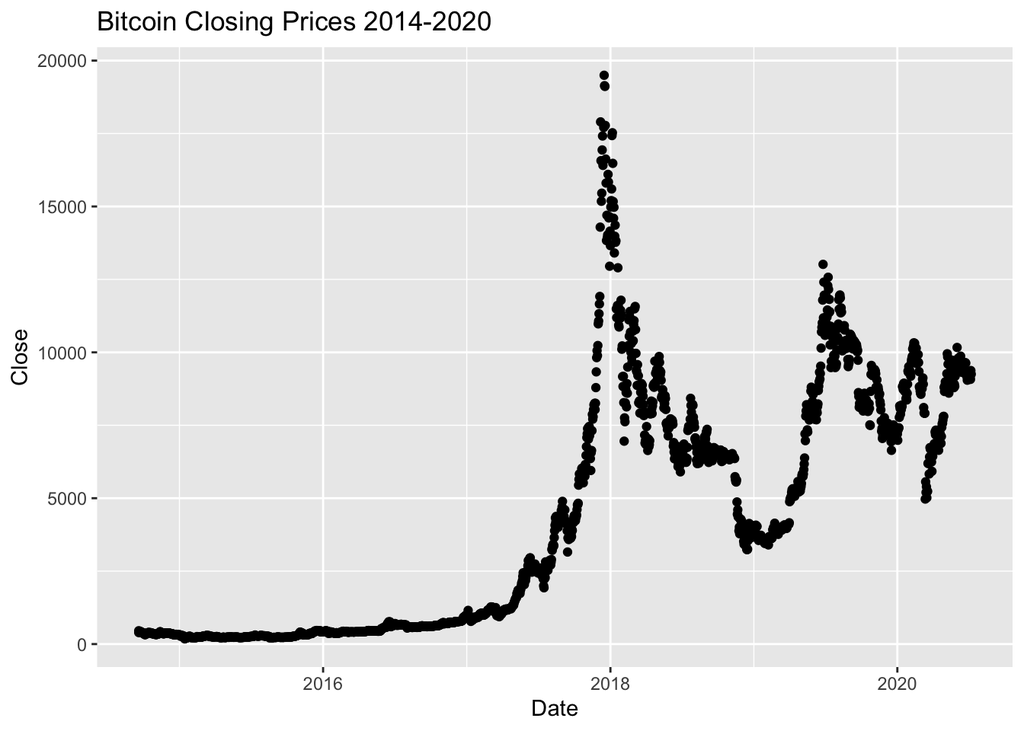

```r
# Pull bitcoin data
data <- read.csv("BTC.csv")
# Or use this if you have any other cryto csv file, data <- read.csv(file.choose(), header = T)
# Clean date formating if need be
data$Date <- dmy(data$Date)
# Plot bitcoin historical data
qplot(Date, Close, data = data,
      main = 'Bitcoin Closing Prices 2014-2020')
```

### Plotted Historical Closing Data Logarithmically

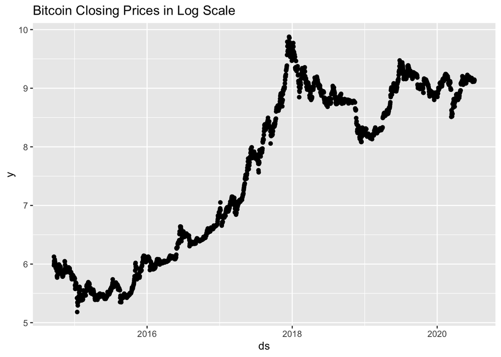

```r
# Log transformation
ds <- data$Date
y <- log(data$Close)
df <- data.frame(ds, y)
# Plot log transformation
qplot(ds, y, data = df,
      main = 'Bitcoin Closing Prices in Log Scale')
```

### Bitcoin Forecast Pricing

This will pull a year of foretasted data forward from 07/07/2020.

```r
# Forecasting with Facebook's prophet package
m <- prophet(df)
future <- make_future_dataframe(m, periods = 365)
forecast <- predict(m, future)
```

### Forecast Plotting

```r
# Plot forecast
dyplot.prophet(m, forecast)
```

[interactive chart not shown]

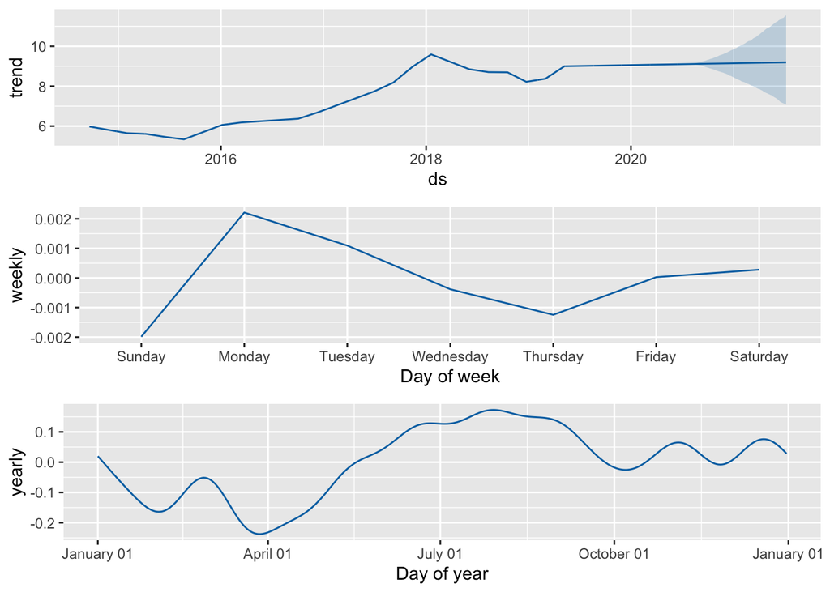

```r
prophet_plot_components(m, forecast)
```

### Model Performance

The yhat value is taken from the forecast as it is the predicted value from the modeling. This value and the first 2121 points of it (all current values) are taken and plotted against actual closing prices.

From this model, a trendline is plotted along with the points. This plot gives an ideal linear graph. Running a summary gives Multiple R-squared values of 0.9935. This value tells us that this model is explaining 99.35% of the variability.

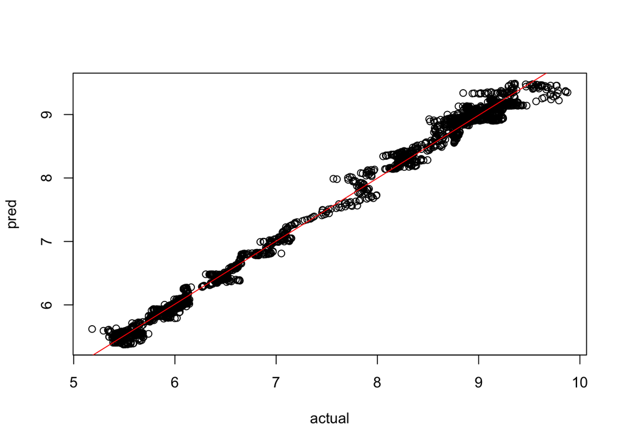

```r
# Model performance
pred <- forecast$yhat[1:2121]
actual <- m$history$y
plot(actual, pred)
abline(lm(pred~actual), col = 'red')
```

```r
summary(lm(pred~actual))
```

```
##
## Call:
## lm(formula = pred ~ actual)
##
## Residuals:
##      Min       1Q   Median       3Q      Max
## -0.55443 -0.07032  0.00122  0.06725  0.50131
##
## Coefficients:
##             Estimate Std. Error t value Pr(>|t|)
## (Intercept)  0.05726    0.01339   4.275 1.99e-05 ***
## actual       0.99243    0.00174 570.219  < 2e-16 ***
## ---
## Signif. codes:  0 '***' 0.001 '**' 0.01 '*' 0.05 '.' 0.1 ' ' 1
##
## Residual standard error: 0.115 on 2119 degrees of freedom
## Multiple R-squared:  0.9935, Adjusted R-squared:  0.9935
## F-statistic: 3.252e+05 on 1 and 2119 DF,  p-value: < 2.2e-16
```

```r
x <- cross_validation(m, 365, units = 'days')
performance_metrics(x, rolling_window = 0.1)
```

```
##        horizon       mse      rmse       mae       mape  coverage
## 1    876 hours 0.1083186 0.3291180 0.2417139 0.02742262 0.3904110
## 2    888 hours 0.1083522 0.3291690 0.2420501 0.02745294 0.3972603
## 3    900 hours 0.1147304 0.3387187 0.2496820 0.02833604 0.3904110
## 4    912 hours 0.1146537 0.3386056 0.2495879 0.02831688 0.3972603
## 5    924 hours 0.1200455 0.3464759 0.2565296 0.02911408 0.3904110
## 6    936 hours 0.1198768 0.3462324 0.2560052 0.02904762 0.3972603
## 7    948 hours 0.1248586 0.3533533 0.2631934 0.02986597 0.3835616
## 8    960 hours 0.1248645 0.3533617 0.2632535 0.02986613 0.3835616
## 9    972 hours 0.1298501 0.3603472 0.2700664 0.03064252 0.3698630
## 10   984 hours 0.1296502 0.3600698 0.2693200 0.03055687 0.3835616
## 11   996 hours 0.1340774 0.3661657 0.2760441 0.03131887 0.3698630
## 12  1008 hours 0.1338808 0.3658972 0.2751023 0.03121008 0.3835616
## 13  1020 hours 0.1393453 0.3732898 0.2830139 0.03210501 0.3698630
## 14  1032 hours 0.1392898 0.3732155 0.2827011 0.03206666 0.3835616
```

[output cut: 644 more lines]

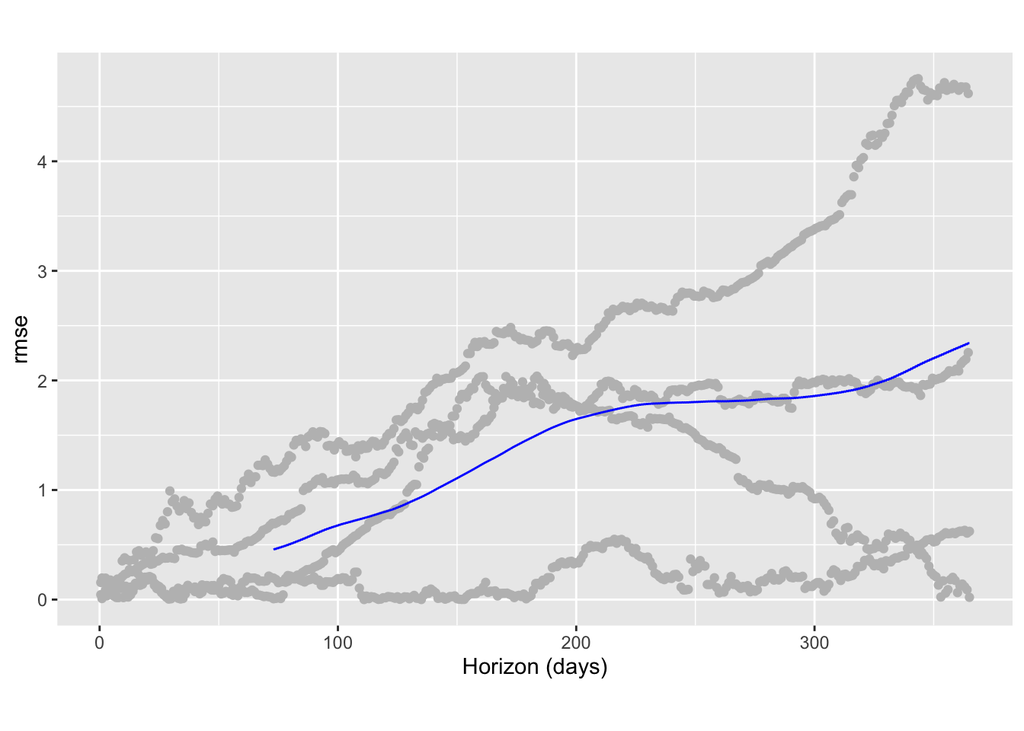

```r
plot_cross_validation_metric(x,
                             metric = 'rmse',
                             rolling_window = 0.2)
```